# Exploring Neural Activity in Steinmetz Mouse Experiment

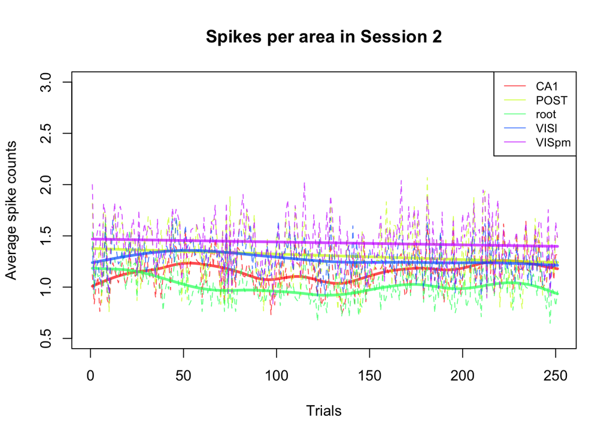

```r
#session 2
plot_spike_counts(2)
```

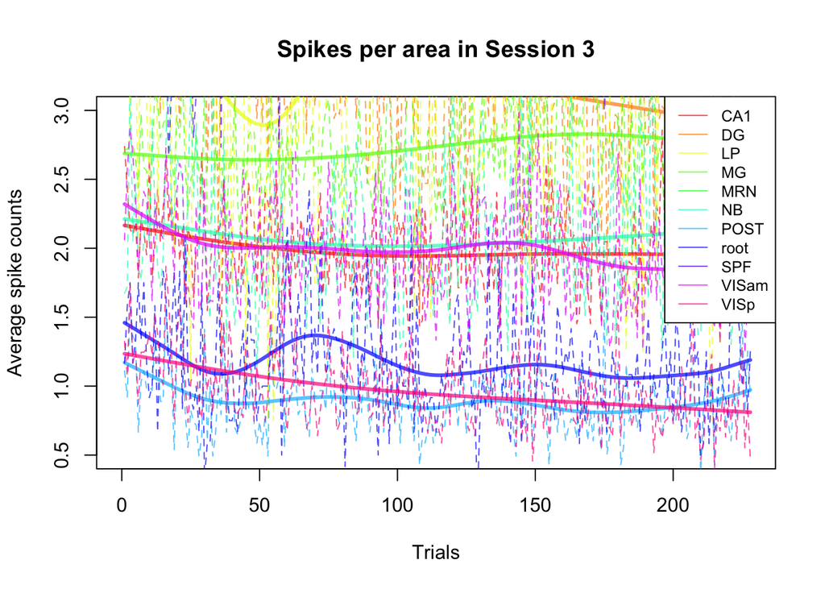

```r
#session 3
plot_spike_counts(3)
```

We can see through these 3 plots that Cory has much higher spike counts for multiple brain areas in the first and last session (session 1 and 3), and much lower spike counts in the middle session (session 2). This could indicate that Cori drastically lost engagement in the middle of the experiment, hence the neurons in many areas of his brain were not responsive to the stimuli.

We will now be investigating whether these neuron activity trends are homogeneous/heterogenous across mice. This is important because we would like to know the differences in neuron activity between the two mice in our test data set (Cori and Lederberg) as well as whether the other two mice subjects (Forssman and Hence) show similarity in neuron activity to Cori or Lederberg. In our approach we are choosing one representative session from each mouse (session 1 for Cori, session 18 for Lederberg, session 6 for Forssmann, session 10 for Hench), and examining the neuron spiking activity in first and last trials of their representative sessions. In doing this, we can see how each mouse’s neuron spiking activity changes at the start and end of their trials.

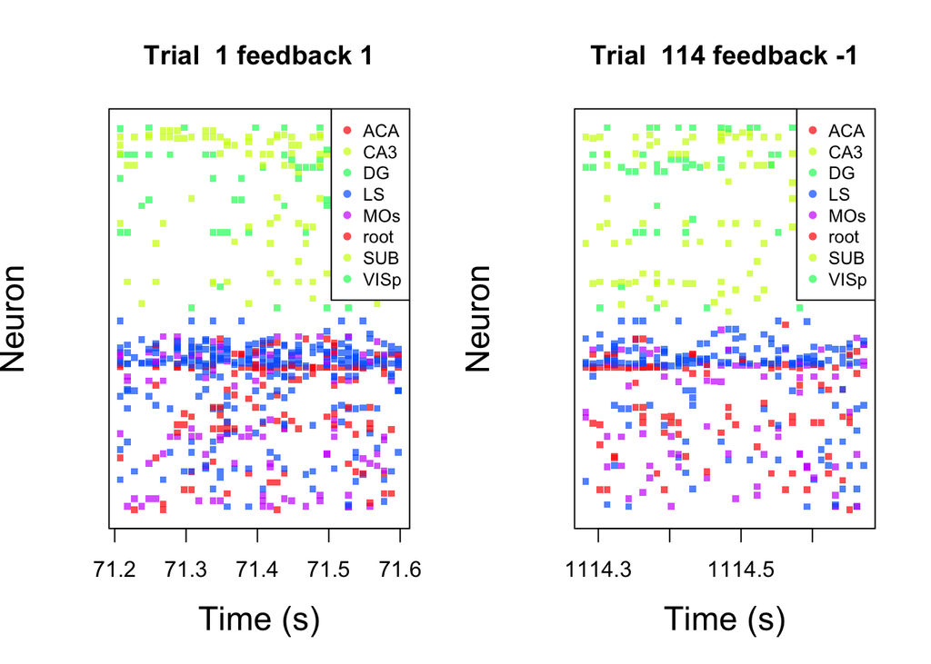

```r
#Cori's beginning and end trial
trial.summary<-process_session(1)
varname=names(trial.summary);
area=varname[1:(length(varname)-4)]
par(mfrow=c(1,2))
plot.trial(1,area, area.col,session[[1]])
plot.trial(114,area, area.col,session[[1]])
```

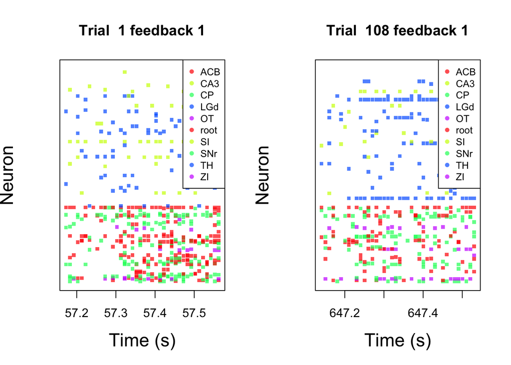

```r
#Lederberg's beginning and end trial
trial.summary<-process_session(18)
varname=names(trial.summary);
area=varname[1:(length(varname)-4)]
par(mfrow=c(1,2))
plot.trial(1,area, area.col,session[[18]])
plot.trial(108,area, area.col,session[[18]])
```

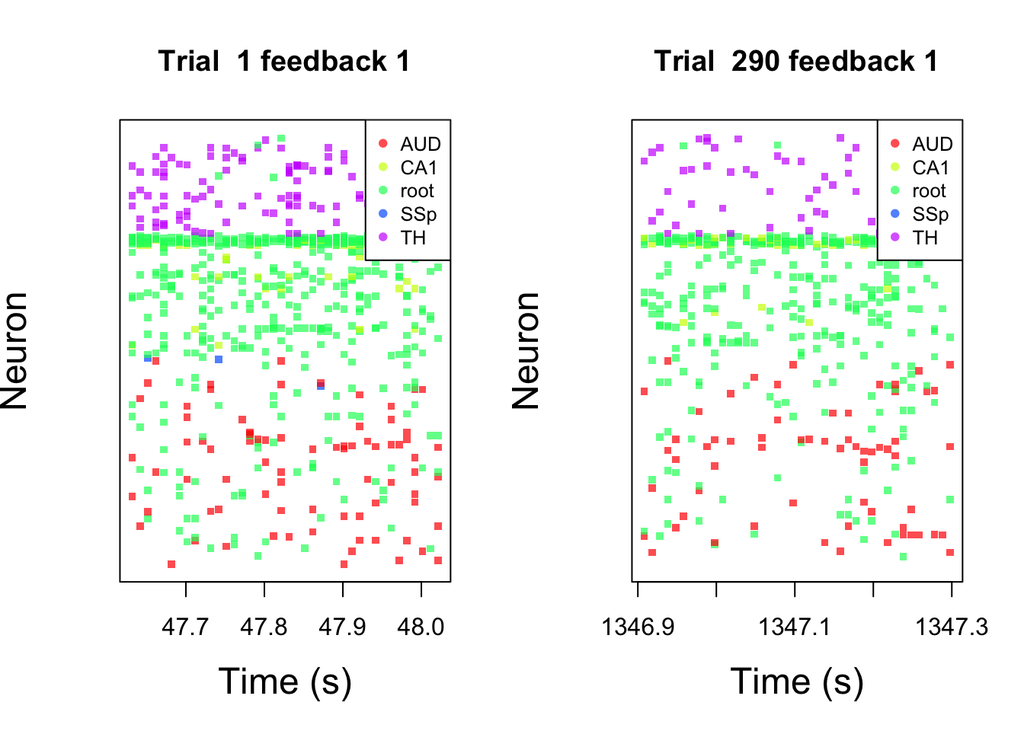

```r
#Forssman's beginning and end trial
trial.summary<-process_session(6)
varname=names(trial.summary);
area=varname[1:(length(varname)-4)]
par(mfrow=c(1,2))
plot.trial(1,area, area.col,session[[6]])
plot.trial(290,area, area.col,session[[6]])
```

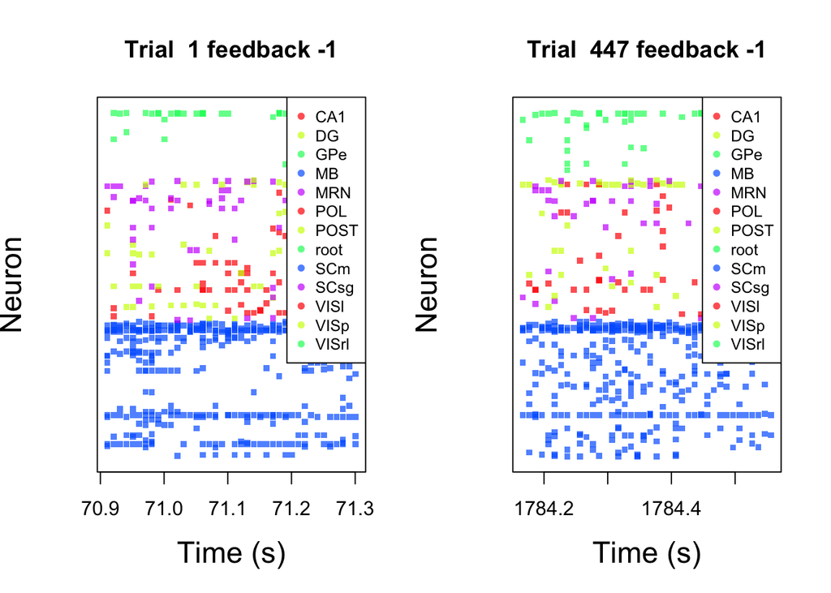

```r
#Hench's beginning and end trial
trial.summary<-process_session(10)
varname=names(trial.summary);
area=varname[1:(length(varname)-4)]
par(mfrow=c(1,2))
plot.trial(1,area, area.col,session[[10]])
plot.trial(447,area, area.col,session[[10]])
```

We can see that for both Cori and Lederberg, the neuron spiking activity in the beginning trial (trial 1 for both mice) has a denser distribution of neuron spikes in the second half of their 0.4 seconds onset. However, the neuron spiking activity in the ending trial (trial 114 for Cori, trial 108 for Lederberg has a denser distribution of neuron spikes in the first half of their 0.4 seconds onset. This trend is especially prevalent in their brain areas CA3 and root.

On the other hand, for both Hench and Forssman, the neuron spiking activity in both the beginning and end trial has a denser distribution of neuron spikes in the first half of their 0.4 seconds onset.

This indicates that for Cori and Lederberg, the neurons in their brain take a longer time to react to stimuli in the beginning of their session but are trained to react faster by the end of the session. On the other hand, for Hench and Forssman, the neurons in their brain take a short time to react to stimuli from the beginning.

## Section 3 Data integration

#i.extracting the shared patters across sessions

```r
#extract trial summary for all 18 sessions first

for (i in 1:18)
{

  # Assign the trial summary to a unique data frame name
  assign(paste0("session", i), process_session(i))
}

#Combine Cori and Lederberg's sessions into one data frame
df_cori <- bind_rows(session1, session2, session3)
head(df_cori)
```

```
## # A tibble: 6 × 22
##     ACA   CA3    DG    LS   MOs  root   SUB  VISp feedback `left contr.`
##   <dbl> <dbl> <dbl> <dbl> <dbl> <dbl> <dbl> <dbl>    <dbl>         <dbl>
## 1 1.27   1.53  2.32 1.94  0.938 0.5    2.08  1.69        1           0
## 2 0.587  1.71  1.56 1.37  0.779 0.667  1.95  1.65        1           0
## 3 1.19   1.99  3.41 1.73  0.920 1.44   2.64  2.28       -1           0.5
## 4 0.514  2.19  2.21 1.06  0.708 1.06   2.8   1.56       -1           0
## 5 0.771  1.81  2.06 1.30  0.788 0.778  2.61  1.62       -1           0
## 6 0.459  1.85  1.06 0.906 0.735 0.611  1.91  1.28        1           0
## # ℹ 12 more variables: `right contr.` <dbl>, id <dbl>, CA1 <dbl>, POST <dbl>,
## #   VISl <dbl>, VISpm <dbl>, LP <dbl>, MG <dbl>, MRN <dbl>, NB <dbl>,
## #   SPF <dbl>, VISam <dbl>
```

```r
df_lederberg <- bind_rows(session13, session14, session15, session16, session17, session18)
head(df_lederberg)
```

```
## # A tibble: 6 × 39
##     ACA   CA1    DG   LGd    MB   MOs   MRN    MS    PL    RN  root   SCm   SCs
##   <dbl> <dbl> <dbl> <dbl> <dbl> <dbl> <dbl> <dbl> <dbl> <dbl> <dbl> <dbl> <dbl>
## 1 0.862 0.618  1.71  1.07  4.44  1.07  5.41  4.22  1.51  8.28  1.71  2.93  2.03
## 2 1.05  0.765  2.18  1.33  3.86  1.17  4.49  4.96  1.64  9.17  1.27  3.8   3.16
## 3 1.5   1.03   1.94  2.16  4.44  1.74  4.80  4.52  1.78 10.1   1.76  4.29  3.81
## 4 1.29  1      2.06  1.46  3.68  1.07  4.88  3.83  1.39  8.95  1.58  3.02  3.12
## 5 1.34  0.765  1.71  1.61  4.02  1.22  5.14  3.65  1.59  9.95  1.59  3.71  3.03
## 6 1.36  0.824  1.35  2.04  3.94  1.93  4.35  4.74  2.05  8.79  2.11  2.91  3.25
## # ℹ 26 more variables: VISam <dbl>, ZI <dbl>, feedback <dbl>,
## #   `left contr.` <dbl>, `right contr.` <dbl>, id <dbl>, ORB <dbl>, PAG <dbl>,
## #   RSP <dbl>, VISp <dbl>, BLA <dbl>, CA3 <dbl>, GPe <dbl>, VPM <dbl>,
## #   SSp <dbl>, SSs <dbl>, TH <dbl>, LD <dbl>, MEA <dbl>, RT <dbl>, VPL <dbl>,
## #   ACB <dbl>, CP <dbl>, OT <dbl>, SI <dbl>, SNr <dbl>
```

```r
library(plyr)
combined_df <- rbind.fill(df_cori, df_lederberg)
head(combined_df)
```

```
##         ACA      CA3       DG        LS       MOs      root      SUB     VISp
## 1 1.2660550 1.529412 2.323529 1.9352518 0.9380531 0.5000000 2.080000 1.685393
## 2 0.5871560 1.705882 1.558824 1.3669065 0.7787611 0.6666667 1.946667 1.651685
## 3 1.1926606 1.985294 3.411765 1.7266187 0.9203540 1.4444444 2.640000 2.275281
## 4 0.5137615 2.191176 2.205882 1.0575540 0.7079646 1.0555556 2.800000 1.561798
## 5 0.7706422 1.808824 2.058824 1.3021583 0.7876106 0.7777778 2.613333 1.623596
## 6 0.4587156 1.852941 1.058824 0.9064748 0.7345133 0.6111111 1.906667 1.280899
##   feedback left contr. right contr. id CA1 POST VISl VISpm LP MG MRN NB SPF
## 1        1         0.0          0.5  1  NA   NA   NA    NA NA NA  NA NA  NA
## 2        1         0.0          0.0  2  NA   NA   NA    NA NA NA  NA NA  NA
## 3       -1         0.5          1.0  3  NA   NA   NA    NA NA NA  NA NA  NA
## 4       -1         0.0          0.0  4  NA   NA   NA    NA NA NA  NA NA  NA
## 5       -1         0.0          0.0  5  NA   NA   NA    NA NA NA  NA NA  NA
## 6        1         0.0          0.0  6  NA   NA   NA    NA NA NA  NA NA  NA
##   VISam LGd MB MS PL RN SCm SCs ZI ORB PAG RSP BLA GPe VPM SSp SSs TH LD MEA RT
## 1    NA  NA NA NA NA NA  NA  NA NA  NA  NA  NA  NA  NA  NA  NA  NA NA NA  NA NA
## 2    NA  NA NA NA NA NA  NA  NA NA  NA  NA  NA  NA  NA  NA  NA  NA NA NA  NA NA
## 3    NA  NA NA NA NA NA  NA  NA NA  NA  NA  NA  NA  NA  NA  NA  NA NA NA  NA NA
## 4    NA  NA NA NA NA NA  NA  NA NA  NA  NA  NA  NA  NA  NA  NA  NA NA NA  NA NA
## 5    NA  NA NA NA NA NA  NA  NA NA  NA  NA  NA  NA  NA  NA  NA  NA NA NA  NA NA
## 6    NA  NA NA NA NA NA  NA  NA NA  NA  NA  NA  NA  NA  NA  NA  NA NA NA  NA NA
##   VPL ACB CP OT SI SNr
## 1  NA  NA NA NA NA  NA
## 2  NA  NA NA NA NA  NA
## 3  NA  NA NA NA NA  NA
## 4  NA  NA NA NA NA  NA
## 5  NA  NA NA NA NA  NA
## 6  NA  NA NA NA NA  NA
```

#ii.addressing the differences between sessions. Now we determine which brain area had the most frequent spiking activity through all the trials in combined_df by seeing the brain areas with the least number of “NA”s in their average spike count value. We assume that the neuron spiking activity in these brain areas will be the most accurate in helping us predict the feedback type in each trial.

```r
na_counts <- colSums(is.na(combined_df))
na_counts_df <- data.frame(variable = names(na_counts), na_counts = na_counts)
na_counts_df <- na_counts_df[order(na_counts_df$na_counts), ]
head(na_counts_df )
```

```
##                  variable na_counts
## feedback         feedback         0
## left contr.   left contr.         0
## right contr. right contr.         0
## id                     id         0
## root                 root       280
## LGd                   LGd      1085
```

```r
combined_df[is.na(combined_df)] <- 0
```

We find that the top 4 brain areas with the most frequent neuron spiking activity are root, LGd, CA1 and CA3. Earlier our “exploring homogenity/heterogenity in sessions and mice” section we found the neuron spiking trends in the neuron spiking activity of root and CA3 to be representative of Cori and Lederberg’s neuron activity within a session. Therefore we decide use the average spike counts of neurons in root, CA3, LGd, and CA1 a to be the main predictor variables in our prediction model.

## Section 4 Predictive modeling

Since our experimental data is complex, consisting of over 1000 trials across 18 sessions, it is reasonable to assume that there may be a few outlier trials where Cori and Lederberg were distracted or an incident occurred that affected their performance accuracy. To address this, we have chosen to employ LDA on our predictor variables, namely “root,” “CA1,” “CA3,” and “LGd,” to develop a prediction model for our response variable, “feedback.” LDA is a prediction method known to be relatively robust, meaning it can handle outlier data points without significantly compromising its performance.

```r
install.packages("MASS")
library(MASS)
# Prepare the training data

training_data <- combined_df
lda_model1 <- lda(feedback ~ root +  `CA3` + `CA1`+`LGd`, data = training_data)
```

[output not shown]

```r
#obtaining test data
testsession=list()
for(i in 1:2){
  testsession[[i]]=readRDS(paste('~/Downloads/test/test',i,'.rds',sep=''))
}
```

We modify the process_session function from earlier to create a trial summary of test sessions 1 and 2.

```r
process_testsession <- function(session_num) {
  n.trial <- length(testsession[[session_num]]$feedback_type)
  n.area <- length(unique(testsession[[session_num]]$brain_area))

  trial.summary <- matrix(nrow = n.trial, ncol = n.area + 1 + 2 + 1)

  for (i.t in 1:n.trial) {
    trial.summary[i.t,] <- c(average_spike_area(i.t, this_session = testsession[[session_num]]),
                            testsession[[session_num]]$feedback_type[i.t],
                            testsession[[session_num]]$contrast_left[i.t],
                            testsession[[session_num]]$contrast_right[i.t],
                            i.t)
  }

  colnames(trial.summary) <- c(names(average_spike_area(i.t, this_session = testsession[[session_num]])),
                               'feedback', 'left contr.', 'right contr.', 'id')

  trial.summary <- as_tibble(trial.summary)

  return(trial.summary)
}
```

Now we run LDA on both test sessions.

```r
testdata1<-process_testsession(1)
testdata2 <- process_testsession(2)

testdata1$CA1<-0
testdata1$LGd<-0
testdata2$CA1<-0


# Step 4: Use the LDA model for prediction
predictionsdata1 <- predict(lda_model1, newdata = testdata1)
predictionsdata2 <- predict(lda_model1, newdata = testdata2)
# Step 5: Extract the predicted feedback values
predictionsdata1
```

```
## $class
##   [1] 1 1 1 1 1 1 1 1 1 1 1 1 1 1 1 1 1 1 1 1 1 1 1 1 1 1 1 1 1 1 1 1 1 1 1 1 1
##  [38] 1 1 1 1 1 1 1 1 1 1 1 1 1 1 1 1 1 1 1 1 1 1 1 1 1 1 1 1 1 1 1 1 1 1 1 1 1
##  [75] 1 1 1 1 1 1 1 1 1 1 1 1 1 1 1 1 1 1 1 1 1 1 1 1 1 1
## Levels: -1 1
##
## $posterior
##            -1         1
## 1   0.3569944 0.6430056
## 2   0.2877286 0.7122714
## 3   0.2798485 0.7201515
## 4   0.2976298 0.7023702
## 5   0.3034274 0.6965726
## 6   0.3257202 0.6742798
## 7   0.3034274 0.6965726
```

[output cut: 196 more lines]

```r
predictionsdata2
```

```
## $class
##   [1] 1 1 1 1 1 1 1 1 1 1 1 1 1 1 1 1 1 1 1 1 1 1 1 1 1 1 1 1 1 1 1 1 1 1 1 1 1
##  [38] 1 1 1 1 1 1 1 1 1 1 1 1 1 1 1 1 1 1 1 1 1 1 1 1 1 1 1 1 1 1 1 1 1 1 1 1 1
##  [75] 1 1 1 1 1 1 1 1 1 1 1 1 1 1 1 1 1 1 1 1 1 1 1 1 1 1
## Levels: -1 1
##
## $posterior
##            -1         1
## 1   0.2141388 0.7858612
## 2   0.1876973 0.8123027
## 3   0.2436815 0.7563185
## 4   0.1981983 0.8018017
## 5   0.1957568 0.8042432
## 6   0.1893442 0.8106558
## 7   0.1720085 0.8279915
```

[output cut: 196 more lines]

## Section 5 Discussion.

In summary, our prediction model showed limited effectiveness as it consistently predicted a feedback type of “1” in all 100 trials, albeit with varying probabilities. Several flaws in our data analysis contribute to this outcome. Firstly, relying solely on the similarity in mice’s response time does not fully account for the similarity in their overall neuron activity or their performance in the experiment. Moreover, selecting brain areas such as “root,” “CA1,” “CA3,” and “LDd” as significant predictors based on their activity in the most sessions may not have been the most optimal choice.

Additionally, our use of the LDA model has its own limitations. LDA struggles with imbalanced classes, where certain topics or in this case, feedback types, are much more prevalent than others. This may result in inaccurate predictions for the minority classes and inappropriate assignment of probabilities.

To improve our predictions, we need to conduct a more in-depth analysis of our data, focusing on better extraction of neural activity. This will allow us to gain a better understanding of the underlying patterns and enable us to make more accurate predictions for different feedback types.

## References

Steinmetz, N.A., Zatka-Haas, P., Carandini, M. et al. Distributed coding of choice, action and engagement across the mouse brain. Nature 576, 266–273 (2019). https://doi.org/10.1038/s41586-019-1787-x ChatGPT, personal communication, February 11, 2023

OpenAI. (2023). ChatGPT (6/1/2023 version) [Large language model]. https://chat.openai.com